# Reproducible Research: Peer Assessment 1

To set up necessary packages and libraries:

```r
  #to install packages if it is required
  if (!require("dplyr")){
    install.packages("dplyr")
  }
```

```r
  if (!require("ggplot2")){
    install.packages("ggplot2")
  }
  if (!require("lubridate")){
    install.packages("lubridate")
  }
  if (!require("lattice")){
    install.packages("lattice")
  }

  #to install libraries if it is required
  if (!require(dplyr)){
    library(dplyr)
  }

  if (!require(ggplot2)){
    library(ggplot2)
  }
  if (!require(lubridate)){
    library(lubridate)
  }
  if (!require(lattice)){
    library(lattice)
  }
```

### **Copy data source file into work directory!!!**

## Loading and preprocessing the data

The data loading is with: read.csv() function. To change data into tbl format to analyze further:

```r
setwd("D:/Dimon/Coursera/Reproducible_Research/Project1/to_Git")
data<-read.csv("activity.csv")
tbl_data<-tbl_df(data)
rm(data)
head(tbl_data)
```

```
## Source: local data frame [6 x 3]
##
##   steps       date interval
##   (int)     (fctr)    (int)
## 1    NA 2012-10-01        0
## 2    NA 2012-10-01        5
## 3    NA 2012-10-01       10
## 4    NA 2012-10-01       15
## 5    NA 2012-10-01       20
## 6    NA 2012-10-01       25
```

## What is mean total number of steps taken per day?

- to remove NA from the subset

```r
rm_na<-filter(tbl_data,!is.na(steps))
```

- group data, summarize and make the histogram:

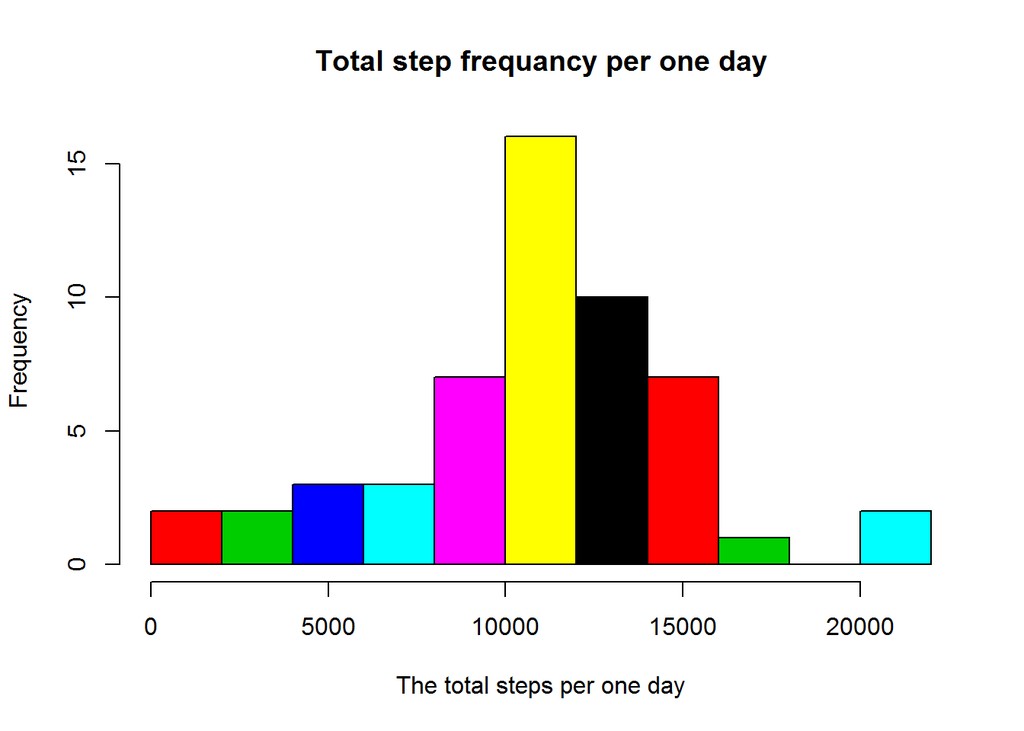

```r
by_date<-group_by(rm_na,date)
total<-summarize(by_date,total=sum(steps))
with(total,hist(total,10,col=date
                ,main="Total step frequancy per one day"
                ,xlab="The total steps per one day"))
```

```r
mean<-mean(total$total)
median<-median(total$total)
```

## What is the average daily activity pattern?

- group data by interval
- calculate mean by interval
- draw a plot

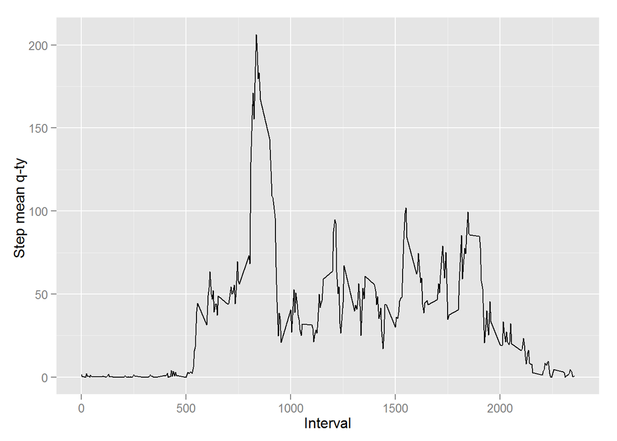

```r
intervals<-group_by(rm_na,interval)
mn_intervals<-summarize(intervals,steps=mean(steps))


g<-ggplot(data=mn_intervals,aes(x=interval,y=steps))+geom_line()+ xlab("Interval")
g<-g+ylab("Step mean q-ty ")
g
```

calculate the maximum number of steps:

```r
max_interval<-mn_intervals[which(mn_intervals$steps==max(mn_intervals$steps)),]$interval
```

the interval with the maximum number of steps is from 835 and 840.  
the max step q-ty is 206.1698113

## Imputing missing values

calculate missing values:

```r
na_steps<-is.na(tbl_data$steps)
na_qty<-sum(na_steps)
```

Total numbe of missing values is 2304

- Join mean interval steps across all days to the original dat set tbl_data:

```r
join_tbl<-left_join(tbl_data,mn_intervals,by="interval")
```

- Assigning the missing stpes field with the mean steps of that interval

```r
join_tbl[na_steps,]$steps.x<-join_tbl[na_steps,]$steps.y
```

- Selecting the needed data set from the joined data set

```r
filled_df<-select(join_tbl,steps=steps.x,date,interval)
```

- grouping the selected data set by date

```r
filled_by_date<-group_by(filled_df,date)
```

- New total stpes taken per day

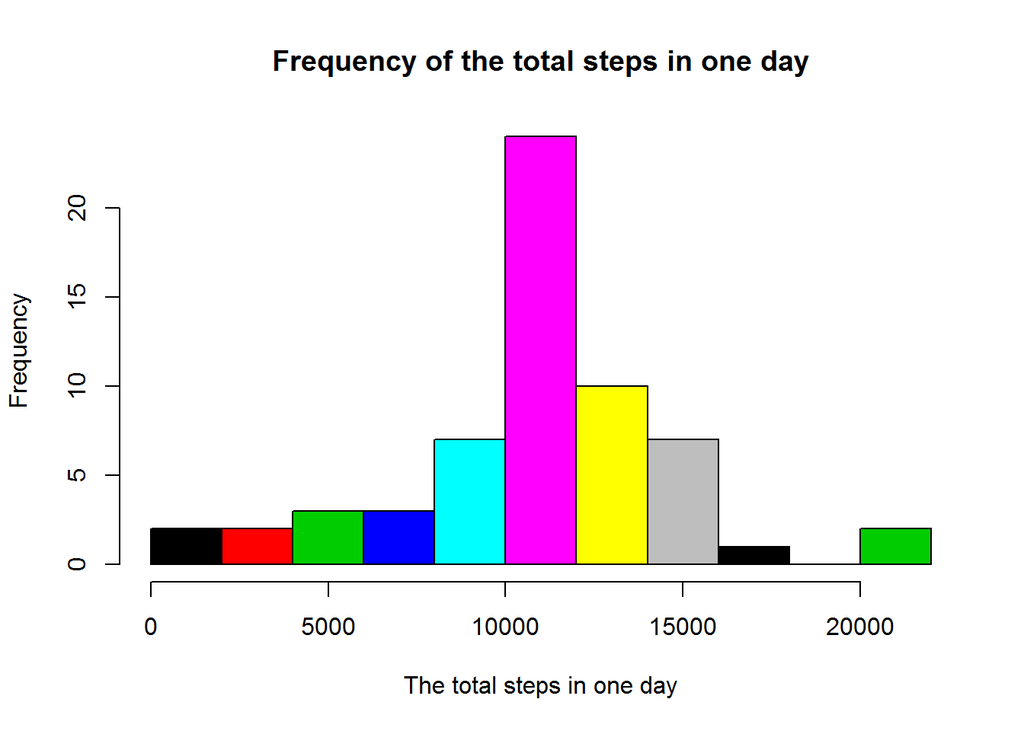

```r
filled_total<-summarize(filled_by_date,total=sum(steps))
with(filled_total,hist(total,10,col=date,
                main="Frequency of the total steps in one day",
                xlab="The total steps in one day"))
```

```r
filled_mean<-summarize(filled_total,mean(total))
filled_median<-summarize(filled_total,quantile(total,probs=0.5))
```

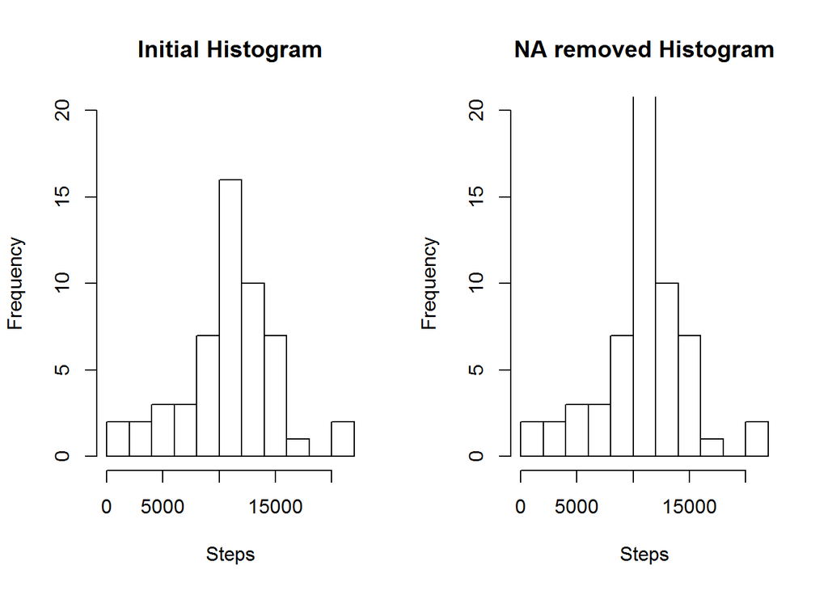

```r
par(mfrow = c(1, 2))
hist(total$total, breaks = 10, xlab = "Steps", main = "Initial Histogram", ylim = c(0, 20))
hist(filled_total$total, breaks = 10, xlab = "Steps", main = "NA removed Histogram", ylim = c(0, 20))
```

The new data set differes from the original one (with missing values).Application of avg numbers leads to a higher distribution (look at the 6th interval).  
Besides averages are the same but medians differ. On the whole, median and avg in both data sets are almost the same.

## Are there differences in activity patterns between weekdays and weekends?

- add new factor coloumn (weekends, weekdays)

```r
filled_df<-mutate(filled_df, weekend=wday(as.Date(filled_df$date), label=TRUE) %in% c('Sat','Sun'))
```

- group the new filled data frame by weekend and interval

```r
filled_by_int_wk<-group_by(filled_df,weekend,interval)
```

- Calcating the average interval mean based on groups

```r
filled_mn_int<-summarize(filled_by_int_wk,steps=mean(steps))

m<-filled_mn_int$weekend==TRUE
index<-which(m %in% c(TRUE))
filled_mn_int$weekend[index]<-"Weekends"

m<-filled_mn_int$weekend==FALSE
index<-which(m %in% c(TRUE))
filled_mn_int$weekend[index]<-"Weekdays"
```

- Plotting the averge interval steps taken per day for the weekday and weekend individually

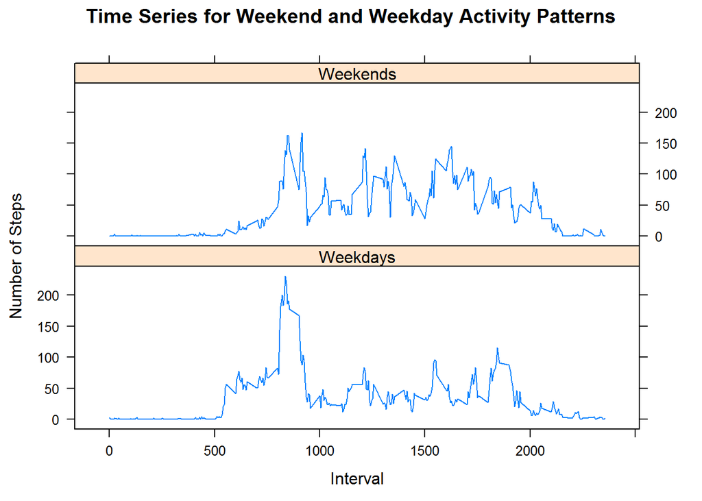

```r
xyplot(steps ~ interval | weekend, filled_mn_int, type = "l", layout = c(1, 2), ylab = "Number of Steps", xlab = "Interval", main = "Time Series for Weekend and Weekday Activity Patterns")
```